# The Age-Structure Archipelagos: America’s Hidden Institutional Geography

Census Data Analysis

2025-07-20

## The Hidden Geography of American Institutions

America’s demographic landscape is far from uniform. Scattered across the continental United States are clusters of counties where age follows neither the gentle curves of normal population pyramids nor the predictable patterns of urban versus rural life. Instead, these places exhibit dramatic concentrations of specific age groups that reveal the hidden institutional architecture of American society.

Using statistical thresholds—national averages plus 1.5 standard deviations—we identified **727 counties** across four distinct archipelagos. These represent not merely statistical outliers, but the direct demographic signatures of American institutional life.

## The Map Reveals Four Archipelagos

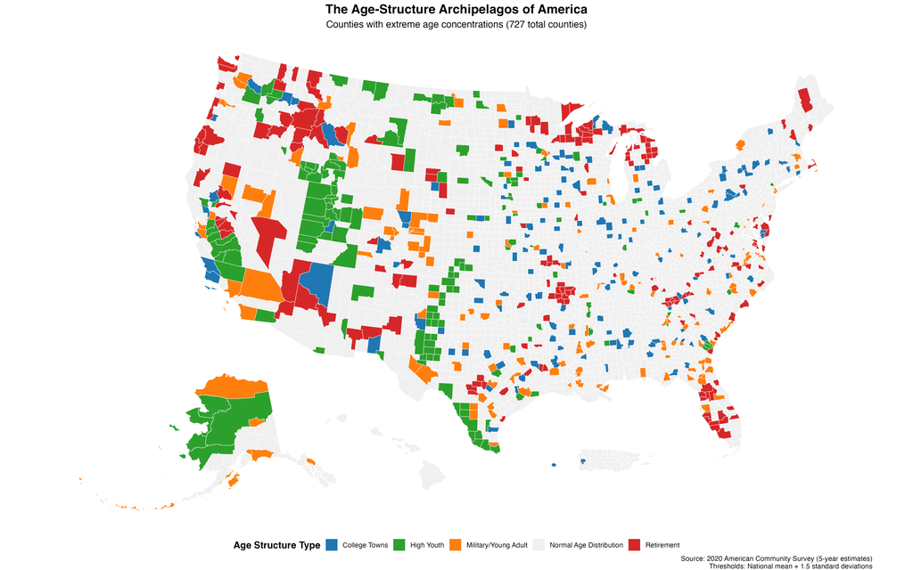

The four age-structure archipelagos of America, showing 727 counties with extreme age concentrations that reveal institutional patterns

The national map instantly resolves into four distinct patterns, each telling a different story about how American institutions concentrate populations:

**Blue clusters** mark college towns where students create youth bulges. **Orange concentrations** indicate military installations and urban centers attracting young professionals. **Green patches** reveal communities with exceptionally high child populations, often Native American reservations or high-fertility rural areas. **Red concentrations** show retirement destinations where seniors dominate.

What emerges is not random demographic variation, but the systematic geographic organization of American institutional life. Each colored cluster represents hundreds of thousands of Americans whose life choices and circumstances have been shaped by the specialized institutions that define these places.

## Four Stories of Institutional Concentration

### The College Archipelago: Where Youth Concentrates Around Learning

**180 counties** where 18-24 year-olds comprise over 14.0% of the population (national average: 8.8%)

American universities create some of the most extreme demographic concentrations in the country. **Lexington city, Virginia, VA** leads the nation with an extraordinary **48.7%** of its 7,205 residents in the 18-24 age bracket—home to Virginia Military Institute and Washington & Lee University.

The college archipelago extends across familiar names: **Radford city, Virginia, VA** (42.6% college-age), **Whitman County, Washington** (34.8%, Washington State University), and **Story County, Iowa** (30.5%, Iowa State University). These aren’t just counties with colleges—they’re communities where the institutional presence of higher education fundamentally reshapes local demographics.

The pattern reveals the geography of American higher education investment. College towns cluster in the Midwest and South, reflecting historical patterns of land-grant university placement and state higher education systems. Virginia’s concentration of high-percentage college counties reflects both its military academies and historic private institutions.

What distinguishes true college counties from mere university towns is the intensity of demographic concentration. In **Lexington city, Virginia**, nearly half the population falls into the prime undergraduate years—a demographic structure that would be mathematically impossible without institutional concentration. These communities represent the most extreme examples of age-specific institutional clustering in America.

### The Military and Young Professional Archipelago: Peak Career Concentration

**194 counties** where 25-34 year-olds comprise over 15.3% of the population (national average: 12.1%)

The 25-34 age bracket captures Americans in their prime career-establishment years, and its geographic concentration reveals two distinct institutional patterns. **Childress, TX** shows **25.7%** concentration in this age group—a rural Texas county whose demographic profile likely reflects correctional or other institutional populations.

More visible are the urban concentrations: **Arlington County, Virginia** (24.1%) represents the classic Washington D.C. corridor pattern of young professionals, while **San Francisco County, California** (23.4%) and **Denver County, Colorado** (23.4%) show how major cities attract peak-career workers. These urban clusters reflect America’s knowledge economy geography, where young professionals concentrate in expensive coastal and mountain cities.

Military installations create another distinct pattern within this archipelago. Counties containing major military bases show elevated 25-34 concentrations that reflect both active-duty service members and the civilian workforce that supports military operations. The geographic spread of military counties—from **Geary County, Kansas** (Fort Riley) to **Onslow County, North Carolina** (Camp Lejeune)—traces America’s defense infrastructure.

Unlike college towns, which create nearly homogeneous age structures, military and young professional concentrations operate within broader demographic contexts. These counties attract specific career-stage populations while maintaining more diverse overall age structures, reflecting the complex institutional ecosystems that support both specialized institutions and broader community life.

### The Youth Archipelago: Where Children Predominate

**160 counties** where under-18 populations comprise over 27.1% of the population (national average: 22.0%)

The most dramatic youth concentrations in America occur in counties where over 40% of residents are under 18—demographic structures that reveal distinct cultural and economic patterns. **Todd, SD** shows the nation’s highest concentration at **41.9%** under-18 population, reflecting the demographic characteristics of the Rosebud Indian Reservation.

Native American reservations feature prominently in the youth archipelago: **Kusilvak Census Area, Alaska** (40.5%), **Dewey County, South Dakota** (36.9%), and **Oglala Lakota County, South Dakota** (36.7%) all show extreme youth concentrations. These patterns reflect both higher birth rates and economic factors that shape age-selective migration patterns in Native American communities.

Texas counties also appear frequently in the youth archipelago, but for different reasons. **Gaines County, Texas** (35.8%) and **Jim Hogg County, Texas** (34.6%) reflect the demographic patterns of Hispanic communities with higher fertility rates and multi-generational household structures. These counties represent a different type of institutional pattern—cultural and familial institutions rather than formal organizational ones.

Utah’s representation in the youth archipelago tells yet another story: **Morgan County, Utah** (35.5%), **Juab County, Utah** (34.3%), and **Utah County, Utah** (33.3% in a population over 600,000) reflect the demographic impact of Mormon cultural institutions that encourage larger families. The scale of Utah County’s youth concentration—over 200,000 children in a single county—represents one of the largest absolute youth concentrations in America.

### The Retirement Archipelago: The Geography of American Aging

**193 counties** where 65+ populations comprise over 25.4% of the population (national average: 18.8%)

Florida’s retirement industry has created the most extreme age concentrations in America. **Sumter, FL** shows an extraordinary **57.8%** of its 129,938 residents over age 65—The Villages, America’s largest planned retirement community.

The Florida retirement corridor extends north through **Charlotte County** (40.1% seniors) and encompasses much of the state’s Gulf Coast. These communities represent the industrialization of American retirement—purpose-built environments designed to concentrate senior populations and the services they require.

But the retirement archipelago extends far beyond Florida’s planned communities. **La Paz County, Arizona** (39.8%) and **Northumberland County, Virginia** (38.5%) show how retirement concentration occurs in scenic rural areas that attract retirees seeking lower costs and different lifestyles. **Llano County, Texas** (37.2%) represents the Hill Country retirement pattern, while Michigan’s Upper Peninsula counties like **Ontonagon County** (36.3%) show “aging in place” patterns in rural areas experiencing youth out-migration.

The retirement archipelago reveals the economic geography of American aging. Some concentrations result from active destination retirement (Florida, Arizona), others from rural youth out-migration leaving aging populations behind (rural Michigan, rural Texas), and still others from specific amenities that attract retirees (mountain counties, coastal areas, small towns with healthcare infrastructure).

What unites the retirement archipelago is not just the demographic pattern, but the economic infrastructure required to support senior-majority populations: specialized healthcare systems, service industries adapted to older consumers, housing markets oriented toward senior needs, and local governance structures responsive to senior priorities.

## The Statistical Foundation

Statistical thresholds for identifying age-structure archipelagos (National mean + 1.5 standard deviations)

[output not shown]

These thresholds represent statistically meaningful deviations from national age distribution patterns. Counties exceeding these thresholds show age concentrations extreme enough to indicate institutional rather than natural demographic processes.

The **727 total counties** represent only **22.6%** of all U.S. counties, but they contain distinctive institutional concentrations that serve much broader populations. A college town like Story County, Iowa, serves students from across the Midwest; military counties support national defense infrastructure; retirement communities attract seniors from across the country.

## The Archipelago Effect: Institutional Geography in America

The four age-structure archipelagos: statistical summary

| Archipelago | Counties | Avg. Concentration | Median Population | % of Total |
| --- | --- | --- | --- | --- |
| 25-34 (Young Adults) | 194 | 0.1723158 | 96708.0 | 26.7% |
| 65+ (Seniors) | 193 | 0.2879396 | 17660.0 | 26.5% |
| 18-24 (College Age) | 180 | 0.1952220 | 61405.5 | 24.8% |
| Under 18 | 160 | 0.3002863 | 26483.5 | 22.0% |

The archipelago metaphor captures something essential about American institutional geography. Like oceanic island chains, these demographic concentrations appear scattered across the national landscape, but closer examination reveals systematic patterns. College towns cluster around state university systems. Military counties trace strategic placement of defense infrastructure. Youth concentrations follow cultural and economic divides. Retirement areas reflect regional amenities and cost structures.

Each archipelago represents a different aspect of American institutional development. The college archipelago traces the democratic expansion of higher education, particularly land-grant institutions that brought universities to rural areas. The military archipelago reflects strategic decisions about base placement and force structure. The youth archipelago reveals cultural variations in family structure and economic opportunity. The retirement archipelago shows the modern industrialization of aging and the geographic redistribution of senior populations.

These patterns matter for policy and planning. Counties within each archipelago share similar challenges and opportunities. College counties must balance permanent resident needs against student populations. Military counties depend on defense spending decisions made in distant Washington. Youth-concentrated counties need educational and economic infrastructure to support growing populations. Retirement counties require healthcare and service infrastructure adapted to senior needs.

## Beyond Demographics: The Institutional Signature

The age-structure archipelagos reveal something profound about American society: how institutional choices create geographic patterns that persist across decades. The demographic signatures we observe today reflect institutional decisions made generations ago—the placement of land-grant universities, the location of military installations, the development of retirement communities, the historical patterns of migration and settlement.

These institutions don’t just serve local populations—they create them. Lexington city, Virginia, doesn’t naturally produce half its population in the 18-24 age bracket; it attracts and concentrates young people through institutional design. Sumter County, Florida, doesn’t naturally age to 58% senior population; it industrially produces senior concentration through planned community development.

The archipelago perspective suggests that much of what we consider “natural” demographic variation actually reflects institutional geography. Places don’t just happen to have certain age structures—they develop specialized age structures through institutional investment and design. Understanding this process helps explain not just where Americans live, but why they live where they do, and how institutional decisions shape the geographic distribution of American life.

In an era of increasing geographic mobility and institutional choice, the age-structure archipelagos may be intensifying rather than diminishing. As Americans gain more freedom to choose where to live based on life stage and institutional affiliation, we might expect these demographic concentrations to become more rather than less pronounced, creating an increasingly specialized institutional geography across the American landscape.

### Technical Notes

**Data**: 2020 American Community Survey 5-year estimates, county level, 3,221 counties analyzed  
**Geographic Coverage**: All U.S. counties with population >5,000  
**Statistical Method**: National mean + 1.5 standard deviations threshold for each age group  
**Classification**: Counties meeting threshold for any age group included in respective archipelago  
**Total Coverage**: 727 counties (22.6% of U.S. counties)